# Predicting Stock Returns with Cluster-Then-Predict

Quang Duong

2017-07-25

In the second lecture sequence this week, we heard about cluster-then-predict, a methodology in which you first cluster observations and then build cluster-specific prediction models. In the lecture sequence, we saw how this methodology helped improve the prediction of heart attack risk. In this assignment, we’ll use cluster-then-predict to predict future stock prices using historical stock data.

When selecting which stocks to invest in, investors seek to obtain good future returns. In this problem, we will first use clustering to identify clusters of stocks that have similar returns over time. Then, we’ll use logistic regression to predict whether or not the stocks will have positive future returns.

For this problem, we’ll use StocksCluster.csv, which contains monthly stock returns from the NASDAQ stock exchange. The NASDAQ is the second-largest stock exchange in the world, and it lists many technology companies. The stock price data used in this problem was obtained from infochimps, a website providing access to many datasets.

Each observation in the dataset is the monthly returns of a particular company in a particular year. The years included are 2000-2009. The companies are limited to tickers that were listed on the exchange for the entire period 2000-2009, and whose stock price never fell below $1. So, for example, one observation is for Yahoo in 2000, and another observation is for Yahoo in 2001. Our goal will be to predict whether or not the stock return in December will be positive, using the stock returns for the first 11 months of the year.

This dataset contains the following variables:

ReturnJan = the return for the company’s stock during January (in the year of the observation). ReturnFeb = the return for the company’s stock during February (in the year of the observation). ReturnMar = the return for the company’s stock during March (in the year of the observation). ReturnApr = the return for the company’s stock during April (in the year of the observation). ReturnMay = the return for the company’s stock during May (in the year of the observation). ReturnJune = the return for the company’s stock during June (in the year of the observation). ReturnJuly = the return for the company’s stock during July (in the year of the observation). ReturnAug = the return for the company’s stock during August (in the year of the observation). ReturnSep = the return for the company’s stock during September (in the year of the observation). ReturnOct = the return for the company’s stock during October (in the year of the observation). ReturnNov = the return for the company’s stock during November (in the year of the observation). PositiveDec = whether or not the company’s stock had a positive return in December (in the year of the observation). This variable takes value 1 if the return was positive, and value 0 if the return was not positive. For the first 11 variables, the value stored is a proportional change in stock value during that month. For instance, a value of 0.05 means the stock increased in value 5% during the month, while a value of -0.02 means the stock decreased in value 2% during the month.

## Exploring the Dataset

Load StocksCluster.csv into a data frame called “stocks”. How many observations are in the dataset?

```r
stocks <- read.csv("StocksCluster.csv")
str(stocks)
```

```
'data.frame':   11580 obs. of  12 variables:
 $ ReturnJan  : num  0.0807 -0.0107 0.0477 -0.074 -0.031 ...
 $ ReturnFeb  : num  0.0663 0.1021 0.036 -0.0482 -0.2127 ...
 $ ReturnMar  : num  0.0329 0.1455 0.0397 0.0182 0.0915 ...
 $ ReturnApr  : num  0.1831 -0.0844 -0.1624 -0.0247 0.1893 ...
 $ ReturnMay  : num  0.13033 -0.3273 -0.14743 -0.00604 -0.15385 ...
 $ ReturnJune : num  -0.0176 -0.3593 0.0486 -0.0253 -0.1061 ...
 $ ReturnJuly : num  -0.0205 -0.0253 -0.1354 -0.094 0.3553 ...
 $ ReturnAug  : num  0.0247 0.2113 0.0334 0.0953 0.0568 ...
 $ ReturnSep  : num  -0.0204 -0.58 0 0.0567 0.0336 ...
 $ ReturnOct  : num  -0.1733 -0.2671 0.0917 -0.0963 0.0363 ...
 $ ReturnNov  : num  -0.0254 -0.1512 -0.0596 -0.0405 -0.0853 ...
 $ PositiveDec: int  0 0 0 1 1 1 1 0 0 0 ...
```

What proportion of the observations have positive returns in December?

```r
table(stocks$PositiveDec)
(6324)/(6324+5256)
```

```
   0    1
5256 6324
[1] 0.546114
```

What is the maximum correlation between any two return variables in the dataset? You should look at the pairwise correlations between ReturnJan, ReturnFeb, ReturnMar, ReturnApr, ReturnMay, ReturnJune, ReturnJuly, ReturnAug, ReturnSep, ReturnOct, and ReturnNov.

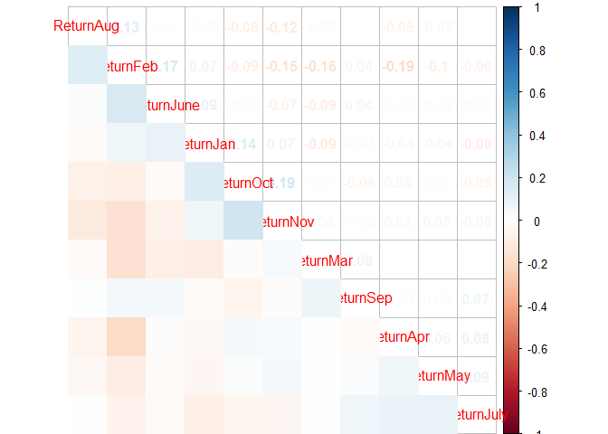

```r
library(corrplot)
corMat <- cor(stocks[,1:11])
corrplot.mixed(corMat, lower = "color", upper = "number", order = "hclust")
```

Which month (from January through November) has the largest mean return across all observations in the dataset?

Which month (from January through November) has the smallest mean return across all observations in the dataset?

```r
summary(stocks)
```

```
   ReturnJan            ReturnFeb           ReturnMar
 Min.   :-0.7616205   Min.   :-0.690000   Min.   :-0.712994
 1st Qu.:-0.0691663   1st Qu.:-0.077748   1st Qu.:-0.046389
 Median : 0.0009965   Median :-0.010626   Median : 0.009878
 Mean   : 0.0126316   Mean   :-0.007605   Mean   : 0.019402
 3rd Qu.: 0.0732606   3rd Qu.: 0.043600   3rd Qu.: 0.077066
 Max.   : 3.0683060   Max.   : 6.943694   Max.   : 4.008621
   ReturnApr           ReturnMay          ReturnJune
 Min.   :-0.826503   Min.   :-0.92207   Min.   :-0.717920
 1st Qu.:-0.054468   1st Qu.:-0.04640   1st Qu.:-0.063966
 Median : 0.009059   Median : 0.01293   Median :-0.000880
 Mean   : 0.026308   Mean   : 0.02474   Mean   : 0.005938
 3rd Qu.: 0.085338   3rd Qu.: 0.08396   3rd Qu.: 0.061566
 Max.   : 2.528827   Max.   : 6.93013   Max.   : 4.339713
   ReturnJuly           ReturnAug           ReturnSep
 Min.   :-0.7613096   Min.   :-0.726800   Min.   :-0.839730
 1st Qu.:-0.0731917   1st Qu.:-0.046272   1st Qu.:-0.074648
 Median :-0.0008047   Median : 0.007205   Median :-0.007616
 Mean   : 0.0030509   Mean   : 0.016198   Mean   :-0.014721
 3rd Qu.: 0.0718205   3rd Qu.: 0.070783   3rd Qu.: 0.049476
 Max.   : 2.5500000   Max.   : 3.626609   Max.   : 5.863980
   ReturnOct           ReturnNov          PositiveDec
 Min.   :-0.685504   Min.   :-0.747171   Min.   :0.0000
 1st Qu.:-0.070915   1st Qu.:-0.054890   1st Qu.:0.0000
 Median : 0.002115   Median : 0.008522   Median :1.0000
 Mean   : 0.005651   Mean   : 0.011387   Mean   :0.5461
 3rd Qu.: 0.074542   3rd Qu.: 0.076576   3rd Qu.:1.0000
 Max.   : 5.665138   Max.   : 3.271676   Max.   :1.0000
```

## Initial Logistic Regression Model

Run the following commands to split the data into a training set and testing set, putting 70% of the data in the training set and 30% of the data in the testing set. Then, use the stocksTrain data frame to train a logistic regression model (name it StocksModel) to predict PositiveDec using all the other variables as independent variables. Don’t forget to add the argument family=binomial to your glm command.

What is the overall accuracy on the training set, using a threshold of 0.5?

```r
library(caTools)
set.seed(144)
spl <- sample.split(stocks$PositiveDec, SplitRatio = 0.7)
stocksTrain <- subset(stocks, spl == TRUE)
stocksTest <- subset(stocks, spl == FALSE)
StocksModel <- glm(PositiveDec ~ ., data = stocksTrain, family = "binomial")
trainPred <- predict(StocksModel, type = "response")
table(stocksTrain$PositiveDec, trainPred >= 0.5)
(990+3640)/(990+3640+2689+787)
```

```
    FALSE TRUE
  0   990 2689
  1   787 3640
[1] 0.5711818
```

Now obtain test set predictions from StocksModel. What is the overall accuracy of the model on the test, again using a threshold of 0.5?

```r
testPred <- predict(StocksModel, newdata = stocksTest, type = "response")
table(stocksTest$PositiveDec, testPred >= 0.5)
(417+1553)/(417+1553+344+1160)
```

```
    FALSE TRUE
  0   417 1160
  1   344 1553
[1] 0.5670697
```

What is the accuracy on the test set of a baseline model that always predicts the most common outcome (PositiveDec = 1)?

```r
table(stocksTest$PositiveDec)
1897/(1577+1897)
```

```
   0    1
1577 1897
[1] 0.5460564
```

## Clustering Stocks

Now, let’s cluster the stocks. The first step in this process is to remove the dependent variable using the following commands:

```r
limitedTrain <- stocksTrain
limitedTrain$PositiveDec <- NULL
limitedTest <- stocksTest
limitedTest$PositiveDec <- NULL
```

Why do we need to remove the dependent variable in the clustering phase of the cluster-then-predict methodology?

Needing to know the dependent variable value to assign an observation to a cluster defeats the purpose of the methodology

In the market segmentation assignment in this week’s homework, you were introduced to the preProcess command from the caret package, which normalizes variables by subtracting by the mean and dividing by the standard deviation.

In cases where we have a training and testing set, we’ll want to normalize by the mean and standard deviation of the variables in the training set. We can do this by passing just the training set to the preProcess function:

```r
library(caret)
prepoc <- preProcess(limitedTrain)
normTrain <- predict(prepoc, limitedTrain)
normTest <- predict(prepoc, limitedTest)
```

What is the mean of the ReturnJan variable in normTrain?

```r
summary(normTrain)
summary(normTest)
```

```
   ReturnJan          ReturnFeb          ReturnMar
 Min.   :-4.57682   Min.   :-3.43004   Min.   :-4.54609
 1st Qu.:-0.48271   1st Qu.:-0.35589   1st Qu.:-0.40758
 Median :-0.07055   Median :-0.01875   Median :-0.05778
 Mean   : 0.00000   Mean   : 0.00000   Mean   : 0.00000
 3rd Qu.: 0.35898   3rd Qu.: 0.25337   3rd Qu.: 0.36106
 Max.   :18.06234   Max.   :34.92751   Max.   :24.77296
   ReturnApr         ReturnMay          ReturnJune
 Min.   :-5.0227   Min.   :-4.96759   Min.   :-4.82957
 1st Qu.:-0.4757   1st Qu.:-0.43045   1st Qu.:-0.45602
 Median :-0.1104   Median :-0.06983   Median :-0.04354
 Mean   : 0.0000   Mean   : 0.00000   Mean   : 0.00000
 3rd Qu.: 0.3400   3rd Qu.: 0.35906   3rd Qu.: 0.37273
 Max.   :14.6959   Max.   :42.69158   Max.   :10.84515
   ReturnJuly         ReturnAug          ReturnSep
 Min.   :-5.19139   Min.   :-5.60378   Min.   :-5.47078
 1st Qu.:-0.51832   1st Qu.:-0.47163   1st Qu.:-0.39604
 Median :-0.02372   Median :-0.07393   Median : 0.04767
 Mean   : 0.00000   Mean   : 0.00000   Mean   : 0.00000
 3rd Qu.: 0.47735   3rd Qu.: 0.39967   3rd Qu.: 0.42287
 Max.   :17.33975   Max.   :27.14273   Max.   :39.05435
   ReturnOct          ReturnNov
 Min.   :-3.53719   Min.   :-4.31684
 1st Qu.:-0.42176   1st Qu.:-0.43564
 Median :-0.01891   Median :-0.01878
 Mean   : 0.00000   Mean   : 0.00000
 3rd Qu.: 0.37451   3rd Qu.: 0.42560
 Max.   :31.25996   Max.   :17.18255
   ReturnJan           ReturnFeb           ReturnMar
 Min.   :-3.743836   Min.   :-3.251044   Min.   :-4.07731
 1st Qu.:-0.485690   1st Qu.:-0.348951   1st Qu.:-0.40662
 Median :-0.066856   Median :-0.006860   Median :-0.05674
 Mean   :-0.000419   Mean   :-0.003862   Mean   : 0.00583
 3rd Qu.: 0.357729   3rd Qu.: 0.264647   3rd Qu.: 0.35653
 Max.   : 8.412973   Max.   : 9.552365   Max.   : 9.00982
   ReturnApr          ReturnMay          ReturnJune
 Min.   :-4.47865   Min.   :-5.84445   Min.   :-4.73628
 1st Qu.:-0.51121   1st Qu.:-0.43819   1st Qu.:-0.44968
 Median :-0.11414   Median :-0.05346   Median :-0.02678
 Mean   :-0.03638   Mean   : 0.02651   Mean   : 0.04315
 3rd Qu.: 0.32742   3rd Qu.: 0.42290   3rd Qu.: 0.43010
 Max.   : 6.84589   Max.   : 7.21362   Max.   :29.00534
   ReturnJuly          ReturnAug          ReturnSep
 Min.   :-5.201454   Min.   :-4.62097   Min.   :-3.57222
 1st Qu.:-0.512039   1st Qu.:-0.51546   1st Qu.:-0.38067
 Median :-0.026576   Median :-0.10277   Median : 0.08215
 Mean   : 0.006016   Mean   :-0.04973   Mean   : 0.02939
 3rd Qu.: 0.457193   3rd Qu.: 0.38781   3rd Qu.: 0.45847
 Max.   :12.790901   Max.   : 6.66889   Max.   : 7.09106
   ReturnOct           ReturnNov
 Min.   :-3.807577   Min.   :-4.881463
 1st Qu.:-0.393856   1st Qu.:-0.396764
 Median : 0.006783   Median :-0.002337
 Mean   : 0.029672   Mean   : 0.017128
 3rd Qu.: 0.419005   3rd Qu.: 0.424617
 Max.   : 7.428466   Max.   :21.007786
```

Why is the mean ReturnJan variable much closer to 0 in normTrain than in normTest?

The distribution of the ReturnJan variable is different in the training and testing set.

Set the random seed to 144 (it is important to do this again, even though we did it earlier). Run k-means clustering with 3 clusters on normTrain, storing the result in an object called km.

Which cluster has the largest number of observations?

```r
set.seed(144)
km <- kmeans(normTrain, centers = 3)
table(km$cluster)
```

```
   1    2    3
3157 4696  253
```

Cluster 2.

Recall from the recitation that we can use the flexclust package to obtain training set and testing set cluster assignments for our observations

```r
library(flexclust)
km.kcca <- as.kcca(km, normTrain)
clusterTrain <- predict(km.kcca)
clusterTest <- predict(km.kcca, newdata = normTest)
```

How many test-set observations were assigned to Cluster 2?

```r
table(clusterTest)
```

```
clusterTest
   1    2    3
1298 2080   96
```

## Cluster-Specific Predictions

Using the subset function, build data frames stocksTrain1, stocksTrain2, and stocksTrain3, containing the elements in the stocksTrain data frame assigned to clusters 1, 2, and 3, respectively (be careful to take subsets of stocksTrain, not of normTrain). Similarly build stocksTest1, stocksTest2, and stocksTest3 from the stocksTest data frame.

```r
stocksTrain1 <- subset(stocksTrain, clusterTrain==1)
stocksTrain2 <- subset(stocksTrain, clusterTrain==2)
stocksTrain3 <- subset(stocksTrain, clusterTrain==3)
stocksTest1 <- subset(stocksTest, clusterTest==1)
stocksTest2 <- subset(stocksTest, clusterTest==2)
stocksTest3 <- subset(stocksTest, clusterTest==3)
```

Which training set data frame has the highest average value of the dependent variable?

```r
mean(stocksTrain1$PositiveDec)
mean(stocksTrain2$PositiveDec)
mean(stocksTrain3$PositiveDec)
```

```
[1] 0.6024707
[1] 0.5140545
[1] 0.4387352
```

Build logistic regression models StocksModel1, StocksModel2, and StocksModel3, which predict PositiveDec using all the other variables as independent variables. StocksModel1 should be trained on stocksTrain1, StocksModel2 should be trained on stocksTrain2, and StocksModel3 should be trained on stocksTrain3.

```r
StocksModel1 <- glm(PositiveDec ~., data = stocksTrain1, family = "binomial")
StocksModel2 <- glm(PositiveDec ~., data = stocksTrain2, family = "binomial")
StocksModel3 <- glm(PositiveDec ~., data = stocksTrain3, family = "binomial")
```

Which variables have a positive sign for the coefficient in at least one of StocksModel1, StocksModel2, and StocksModel3 and a negative sign for the coefficient in at least one of StocksModel1, StocksModel2, and StocksModel3?

```r
summary(StocksModel1)
summary(StocksModel2)
summary(StocksModel3)
```

```
Call:
glm(formula = PositiveDec ~ ., family = "binomial", data = stocksTrain1)

Deviance Residuals:
    Min       1Q   Median       3Q      Max
-2.7307  -1.2910   0.8878   1.0280   1.5023

Coefficients:
            Estimate Std. Error z value Pr(>|z|)
(Intercept)  0.17224    0.06302   2.733  0.00628 **
ReturnJan    0.02498    0.29306   0.085  0.93206
ReturnFeb   -0.37207    0.29123  -1.278  0.20139
ReturnMar    0.59555    0.23325   2.553  0.01067 *
ReturnApr    1.19048    0.22439   5.305 1.12e-07 ***
ReturnMay    0.30421    0.22845   1.332  0.18298
ReturnJune  -0.01165    0.29993  -0.039  0.96901
ReturnJuly   0.19769    0.27790   0.711  0.47685
ReturnAug    0.51273    0.30858   1.662  0.09660 .
ReturnSep    0.58833    0.28133   2.091  0.03651 *
ReturnOct   -1.02254    0.26007  -3.932 8.43e-05 ***
ReturnNov   -0.74847    0.28280  -2.647  0.00813 **
---
Signif. codes:  0 '***' 0.001 '**' 0.01 '*' 0.05 '.' 0.1 ' ' 1

(Dispersion parameter for binomial family taken to be 1)

    Null deviance: 4243.0  on 3156  degrees of freedom
Residual deviance: 4172.9  on 3145  degrees of freedom
AIC: 4196.9

Number of Fisher Scoring iterations: 4


Call:
glm(formula = PositiveDec ~ ., family = "binomial", data = stocksTrain2)

Deviance Residuals:
    Min       1Q   Median       3Q      Max
-2.2012  -1.1941   0.8583   1.1334   1.9424

```

[output cut: 42 more lines]

```
ReturnJuly   0.774164   0.729360   1.061   0.2885
ReturnAug    0.982605   0.533158   1.843   0.0653 .
ReturnSep    0.363807   0.627774   0.580   0.5622
ReturnOct    0.782242   0.733123   1.067   0.2860
ReturnNov   -0.873752   0.738480  -1.183   0.2367
---
Signif. codes:  0 '***' 0.001 '**' 0.01 '*' 0.05 '.' 0.1 ' ' 1

(Dispersion parameter for binomial family taken to be 1)

    Null deviance: 346.92  on 252  degrees of freedom
Residual deviance: 328.29  on 241  degrees of freedom
AIC: 352.29

Number of Fisher Scoring iterations: 4
```

Using StocksModel1, make test-set predictions called PredictTest1 on the data frame stocksTest1. Using StocksModel2, make test-set predictions called PredictTest2 on the data frame stocksTest2. Using StocksModel3, make test-set predictions called PredictTest3 on the data frame stocksTest3.

What is the overall accuracy of StocksModel1 on the test set stocksTest1, using a threshold of 0.5?

```r
PredictTest1 <- predict(StocksModel1, newdata = stocksTest1, type = "response")
PredictTest2 <- predict(StocksModel2, newdata = stocksTest2, type = "response")
PredictTest3 <- predict(StocksModel3, newdata = stocksTest3, type = "response")
table(stocksTest1$PositiveDec, PredictTest1>=0.5)
(30+774)/(30+774+471+23)
```

```
    FALSE TRUE
  0    30  471
  1    23  774
[1] 0.6194145
```

What is the overall accuracy of StocksModel2 on the test set stocksTest2, using a threshold of 0.5? What is the overall accuracy of StocksModel3 on the test set stocksTest3, using a threshold of 0.5?

```r
table(stocksTest2$PositiveDec, PredictTest2>=0.5)
table(stocksTest3$PositiveDec, PredictTest3>=0.5)
(388+757)/(388+757+626+309)
(49+13)/(49+13+21+13)
```

```
    FALSE TRUE
  0   388  626
  1   309  757

    FALSE TRUE
  0    49   13
  1    21   13
[1] 0.5504808
[1] 0.6458333
```

To compute the overall test-set accuracy of the cluster-then-predict approach, we can combine all the test-set predictions into a single vector and all the true outcomes into a single vector:

```r
AllPredictions <- c(PredictTest1, PredictTest2, PredictTest3)
AllOutcomes <- c(stocksTest1$PositiveDec, stocksTest2$PositiveDec, stocksTest3$PositiveDec)
```

What is the overall test-set accuracy of the cluster-then-predict approach, again using a threshold of 0.5?

```r
table(AllOutcomes, AllPredictions >= 0.5)
(467+1544)/(467+1544+1110+353)
```

```
AllOutcomes FALSE TRUE
          0   467 1110
          1   353 1544
[1] 0.5788716
```